# R Notebook

```r
install.packages("rpart.plot")
```

```
Error in install.packages : Updating loaded packages
```

```r
install.packages("ggplot2")
```

```
Error in install.packages : Updating loaded packages
```

```r
install.packages("e1071")
```

```
Error in install.packages : Updating loaded packages
```

A. Data Preparation A.1. Data Loading and Initial Transformation

```r
library(ggplot2)
cc <- read.csv("/Users/christianekwomadu/Documents/US/Schools/Drexel/COURSES/INFO 659 001/Assignment 2/UCI_Credit_Card.csv")

cc = (UCI_Credit_Card)

cc$default.payment.next.month <- factor(cc$default.payment.next.month,levels=c(0,1), labels=c("No","Yes"))
```

A.2. Demographic Variables Discuss how demographic variables have any impact on payment default.

Answers:

1. For Sex:
- According to the histogram below, The size of Female Clients(2) is higher than the size of Male clients(1), which has an impact on the demographic variables by increasing the chances of female clients having higher default in payment than male clients.

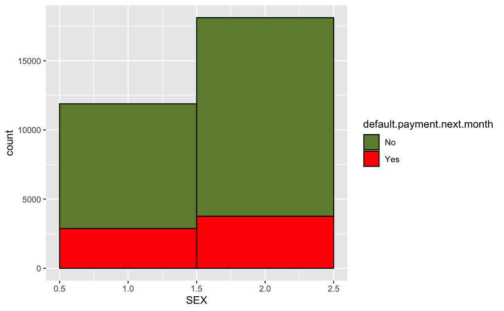

```r
ggplot(cc, aes(x=SEX, fill=default.payment.next.month, color=default.payment.next.month)) +
  geom_histogram(binwidth=1, position="stack") +
  scale_color_manual(values=c("black","black")) +
  scale_fill_manual(values=c("darkolivegreen4", "red"))
```

2. For Education:
- The size of Clients in university(2) is the highest and the variable also has the highest default in payments compared to other clients.
- The size of Clients in Graduate School(1) is the second highest and the variable also has the second highest default in payments compared to other clients.
- The size of Clients in high school(3) is the third highest and the variable also has the third highest default in payments compared to other clients.

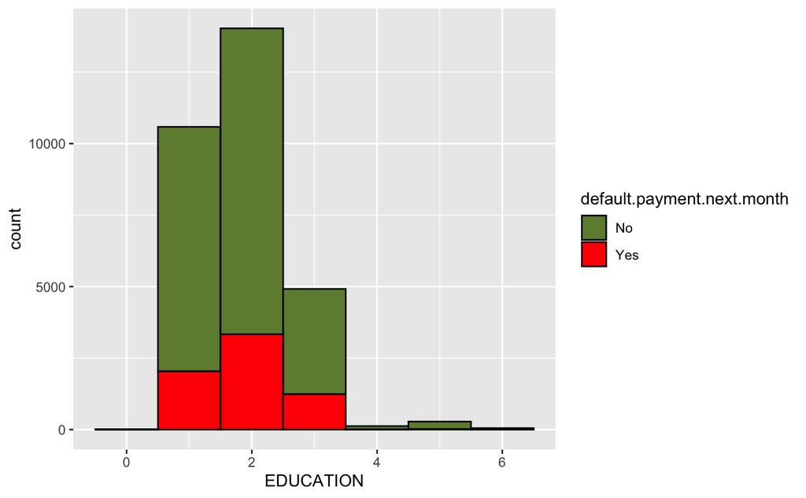

```r
ggplot(cc, aes(x=EDUCATION, fill=default.payment.next.month, color=default.payment.next.month)) +
  geom_histogram(binwidth=1, position="stack") +
  scale_color_manual(values=c("black","black")) +
  scale_fill_manual(values=c("darkolivegreen4", "red"))
```

A.3. Payment Status Variables Discuss how payment status data may have an impact on payment default.

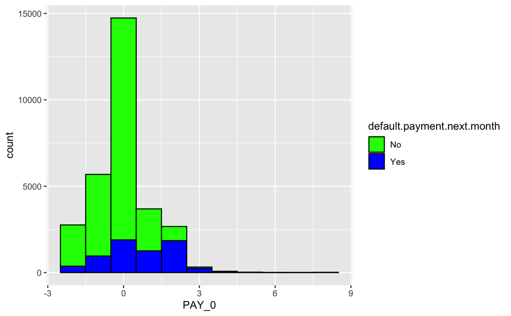

```r
ggplot(cc, aes(x=PAY_0, fill=default.payment.next.month, color=default.payment.next.month)) +
  geom_histogram(binwidth=1, position="stack") +
  scale_color_manual(values=c("black","black")) +
  scale_fill_manual(values=c("green", "blue"))
```

Answer: For Repayment status PAY_0

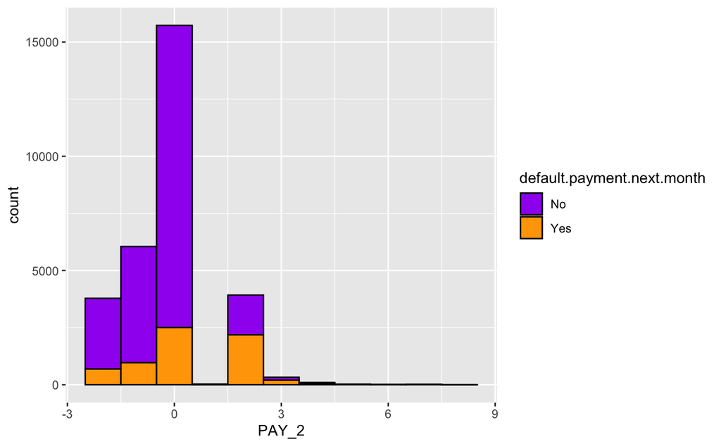

```r
ggplot(cc, aes(x=PAY_2, fill=default.payment.next.month, color=default.payment.next.month)) +
  geom_histogram(binwidth=1, position="stack") +
  scale_color_manual(values=c("black","black")) +
  scale_fill_manual(values=c("purple", "orange"))
```

Answer: For Repayment status PAY_2

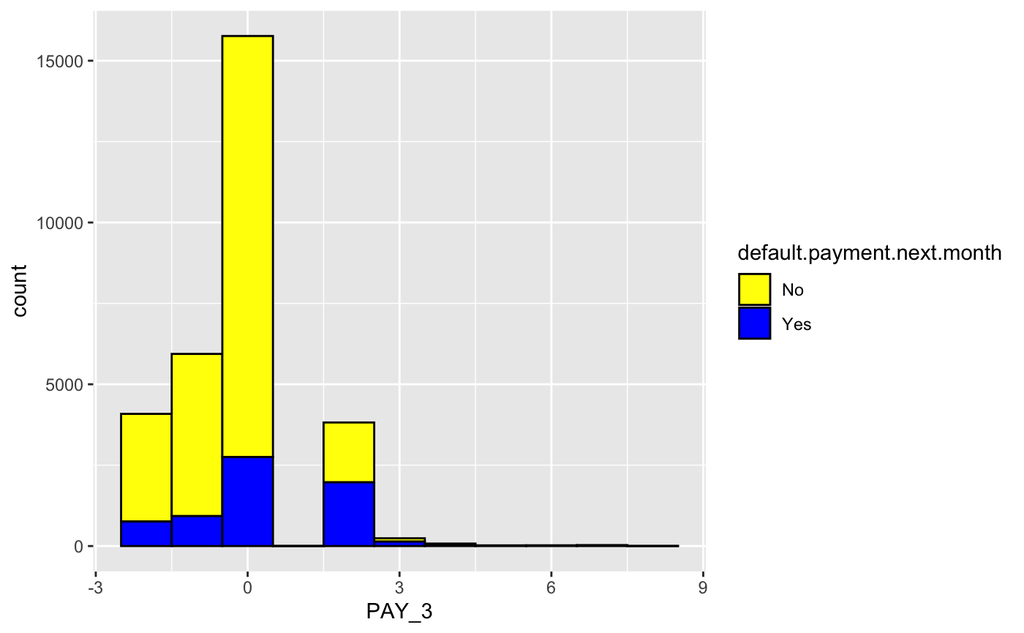

```r
ggplot(cc, aes(x=PAY_3, fill=default.payment.next.month, color=default.payment.next.month)) +
  geom_histogram(binwidth=1, position="stack") +
  scale_color_manual(values=c("black","black")) +
  scale_fill_manual(values=c("yellow", "blue"))
```

Answer: For Repayment status PAY_3

A.4. Transforming Nominal Variables

```r
cc $SEX <- factor(cc $SEX, levels = c(1, 2), labels = c("male", "female"))

cc $MARRIAGE <- factor(cc $MARRIAGE, levels = c(1,2,3), labels = c("married", "single", "other"))

cc $EDUCATION <- factor(cc $EDUCATION, levels = c(1,2,3,4,5,6), labels = c("graduate school", "university", "high school","others","unknown","unknown"))

cc$PAY_0 <- factor(cc$PAY_0,levels=c(-2,-1,0,1,2,3,4,5,6,7,8), labels=c("pay duly", "pay duly", "pay duly",                                                                         "delay 1 mo","delay 2 mo","delay 3 mo",                                                                         "delay 4 mo","delay 5 mo","delay 6 mo",                                                                         "delay 7 mo","delay 8 mo"))

cc$PAY_2 <- factor(cc$PAY_2,levels=c(-2,-1,0,1,2,3,4,5,6,7,8), labels=c("pay duly", "pay duly", "pay duly",                                                                         "delay 1 mo","delay 2 mo","delay 3 mo",                                                                         "delay 4 mo","delay 5 mo","delay 6 mo",                                                                         "delay 7 mo","delay 8 mo"))

cc$PAY_3 <- factor(cc$PAY_3,levels=c(-2,-1,0,1,2,3,4,5,6,7,8), labels=c("pay duly", "pay duly", "pay duly",                                                                         "delay 1 mo","delay 2 mo","delay 3 mo",                                                                         "delay 4 mo","delay 5 mo","delay 6 mo",                                                                         "delay 7 mo","delay 8 mo"))

cc$PAY_4 <- factor(cc$PAY_4,levels=c(-2,-1,0,1,2,3,4,5,6,7,8), labels=c("pay duly", "pay duly", "pay duly",                                                                         "delay 1 mo","delay 2 mo","delay 3 mo",                                                                         "delay 4 mo","delay 5 mo","delay 6 mo",                                                                         "delay 7 mo","delay 8 mo"))

cc$PAY_5 <- factor(cc$PAY_5,levels=c(-2,-1,0,1,2,3,4,5,6,7,8), labels=c("pay duly", "pay duly", "pay duly",                                                                         "delay 1 mo","delay 2 mo","delay 3 mo",                                                                         "delay 4 mo","delay 5 mo","delay 6 mo",                                                                         "delay 7 mo","delay 8 mo"))

cc$PAY_6 <- factor(cc$PAY_6,levels=c(-2,-1,0,1,2,3,4,5,6,7,8), labels=c("pay duly", "pay duly", "pay duly",                                                                         "delay 1 mo","delay 2 mo","delay 3 mo",                                                                         "delay 4 mo","delay 5 mo","delay 6 mo",                                                                         "delay 7 mo","delay 8 mo"))
View(cc)
```

A.5. Selection of Training Data Please select 5000 random rows as training data:

```r
train <- cc[sample(nrow(cc), 5000), ]
```

A.6. Selection of Testing Data Please think of any two random numbers between 1 and 30,000 (the total number of rows in the original data). Use the two number to pick the two rows from data. For example, if you think of 24 and 25358, then using the following code to pick these two rows as test data:

```r
test <- cc[c(150, 11000),]      # please do NOT copy the exact numbers here, use your own numbers!!!
test
```

|  | ID | LIMIT_BAL | SEX | EDUCATION | MARRIAGE | AGE | PAY_0 | PAY_2 | PAY_3 | PAY_4 | PAY_5 | PAY_6 | BILL_AMT1 | BILL_AMT2 | BILL_AMT3 | BILL_AMT4 | BILL_AMT5 | BILL_AMT6 | PAY_AMT1 | PAY_AMT2 | PAY_AMT3 | PAY_AMT4 | PAY_AMT5 | PAY_AMT6 | default.payment.next.month |
| --- | --- | --- | --- | --- | --- | --- | --- | --- | --- | --- | --- | --- | --- | --- | --- | --- | --- | --- | --- | --- | --- | --- | --- | --- | --- |
| 150 | 150 | 260000 | female | graduate school | married | 60 | delay 1 mo | pay duly | pay duly | pay duly | pay duly | pay duly | -1100 | -1100 | 21400 | 0 | 969 | 869 | 0 | 22500 | 0 | 969 | 1000 | 0 | No |
| 11000 | 11000 | 50000 | male | graduate school | single | 23 | pay duly | pay duly | pay duly | pay duly | pay duly | pay duly | 20655 | 21718 | 22316 | 22762 | 20231 | 19445 | 1701 | 1299 | 745 | 711 | 1000 | 685 | No |

B. Data Classification B.1. Naive Bayes using Demographic Variables Naive Bayes model using the nominal demographic variables as predictors:

```r
nbDem <- naiveBayes(default.payment.next.month ~ SEX + EDUCATION + MARRIAGE, train)
nbDem
```

```
Naive Bayes Classifier for Discrete Predictors

Call:
naiveBayes.default(x = X, y = Y, laplace = laplace)

A-priori probabilities:
Y
    No    Yes
0.7812 0.2188

Conditional probabilities:
     SEX
Y          male    female
  No  0.3855607 0.6144393
  Yes 0.4469835 0.5530165

     EDUCATION
Y     graduate school  university high school      others     unknown
  No      0.368596311 0.448258197 0.160860656 0.006403689 0.015881148
  Yes     0.311700183 0.496343693 0.187385740 0.001828154 0.002742230

     MARRIAGE
Y        married     single      other
  No  0.45871795 0.53102564 0.01025641
  Yes 0.47531993 0.51005484 0.01462523
```

Examine the probabilities in the model: pick and compare some of the probability values. Do they make sense?

Answer: Yes

Explain.

Answer:

In the Naive Bayes model, using a training data set (train) of 5000 records, we want to predict the default payment next month based on contributions from various historic independent demographics information. so we set the default payment for next month as the dependent variable. Then we set the various demographics such as SEX, EDUCATION, and MARRIAGE as the independent variables we want our prediction to be based on. From the result above;

1. For the probability of Default in Payment next month based on SEX demographics:
   - Female clients have a higher probability of not defaulting on payment next month than Male clients
   - Female clients also have a higher probability of defaulting on a payment next month than Male clients
2. For the probability of Default in Payment next month based on Marriage demographics:
- Single Clients have a higher probability of not defaulting on payment next month than married clients and other clients
- Single Clients also have a higher probability of defaulting on payment next month than married clients and other clients

Final Thoughts: Using all this information/properties from independent variables, the model is predicting that the probability of a client not defaulting on payment is higher than a client defaulting on payment.

Now run the model on your test data and predict the outcome:

- run the following code to test prediction on first row in the test data;

```r
predict(nbDem, test[1,])
```

```
[1] No
Levels: No Yes
```

-repeat it on the second row in the test data;

```r
predict(nbDem, test[2,])
```

```
[1] No
Levels: No Yes
```

interpret the result, explain whether predictions are correct, and provide your brief observation/reason on why each prediction is correct or incorrect in terms of the model above.

Answer:

Using the test data set in our model, The predictions are correct.

In the first and second rows of the test data set, the client did not default in payment.

B.2. Naive Bayes using Payment Status Build a Naive Bayes model using THREE payment status variables as predictors:

```r
nbPay <- naiveBayes(default.payment.next.month ~ PAY_0 + PAY_2 + PAY_3, train)
nbPay
```

```
Naive Bayes Classifier for Discrete Predictors

Call:
naiveBayes.default(x = X, y = Y, laplace = laplace)

A-priori probabilities:
Y
    No    Yes
0.7812 0.2188

Conditional probabilities:
     PAY_0
Y         pay duly   delay 1 mo   delay 2 mo   delay 3 mo   delay 4 mo   delay 5 mo   delay 6 mo   delay 7 mo
  No  0.8566308244 0.1059907834 0.0340501792 0.0017921147 0.0007680492 0.0007680492 0.0000000000 0.0000000000
  Yes 0.4835466179 0.1864716636 0.2696526508 0.0420475320 0.0109689214 0.0045703839 0.0009140768 0.0000000000
     PAY_0
Y       delay 8 mo
  No  0.0000000000
  Yes 0.0018281536

     PAY_2
Y         pay duly   delay 1 mo   delay 2 mo   delay 3 mo   delay 4 mo   delay 5 mo   delay 6 mo   delay 7 mo
  No  0.9175627240 0.0015360983 0.0742447517 0.0040962622 0.0023041475 0.0002560164 0.0000000000 0.0000000000
  Yes 0.6371115174 0.0018281536 0.3153564899 0.0301645338 0.0118829982 0.0009140768 0.0009140768 0.0018281536
     PAY_2
Y       delay 8 mo
  No  0.0000000000
  Yes 0.0000000000

     PAY_3
Y         pay duly   delay 1 mo   delay 2 mo   delay 3 mo   delay 4 mo   delay 5 mo   delay 6 mo   delay 7 mo
  No  0.9167946749 0.0000000000 0.0780849974 0.0035842294 0.0012800819 0.0000000000 0.0000000000 0.0000000000
  Yes 0.6773308958 0.0009140768 0.2833638026 0.0246800731 0.0091407678 0.0018281536 0.0018281536 0.0009140768
     PAY_3
Y       delay 8 mo
  No  0.0002560164
  Yes 0.0000000000
```

Examine the probabilities in the model: pick and compare some of the probability values. Do they make sense?

Answer: Yes

Explain.

Answer:

In the Naive Bayes model, using a training data set (train) of 5000 records, we want to predict the default payment next month based on contributions from various historic independent demographics information. so we set the default payment for next month as the dependent variable. Then we set the various demographics such as PAY_0, PAY_2, and PAY_3 as the independent variables we want our prediction to be based on. From the result above;

1. For the probability of default in a payment next month based on repayment status in September(PAY_0):
   - clients who pay duly(-1) have the highest probability of not defaulting on payment next month compared to other clients that delay in repayment.
   - Also clients who pay duly(-1) have the highest probability of defaulting on payment next month compared to other clients that delay in repayment.
2. For the probability of default in a payment next month based on repayment status in September(PAY_2):
   - clients who pay duly(-1) have the highest probability of not defaulting on payment next month compared to other clients that delay in repayment.
   - Also clients who pay duly(-1) have the highest probability of defaulting on payment next month compared to other clients that delay in repayment.

Final Thoughts: Using all these information/properties from independent variables, the model is predicting that the probability of a client not defaulting on payment is higher than a client defaulting on payment.

```r
predict(nbPay, test[2,])
```

```
[1] No
Levels: No Yes
```

B.3. Smoothed Naive Bayes using Payment Status

```r
nbPay <- naiveBayes(default.payment.next.month ~ PAY_0 + PAY_2 + PAY_3, train, laplace=1)
nbPay
```

```
Naive Bayes Classifier for Discrete Predictors

Call:
naiveBayes.default(x = X, y = Y, laplace = laplace)

A-priori probabilities:
Y
    No    Yes
0.7812 0.2188

Conditional probabilities:
     PAY_0
Y         pay duly   delay 1 mo   delay 2 mo   delay 3 mo   delay 4 mo   delay 5 mo   delay 6 mo   delay 7 mo
  No  0.8549169860 0.1060025543 0.0342273308 0.0020434227 0.0010217114 0.0010217114 0.0002554278 0.0002554278
  Yes 0.4805077063 0.1858567543 0.2683590209 0.0426110607 0.0117860381 0.0054397099 0.0018132366 0.0009066183
     PAY_0
Y       delay 8 mo
  No  0.0002554278
  Yes 0.0027198549

     PAY_2
Y         pay duly   delay 1 mo   delay 2 mo   delay 3 mo   delay 4 mo   delay 5 mo   delay 6 mo   delay 7 mo
  No  0.9157088123 0.0017879949 0.0743295019 0.0043422733 0.0025542784 0.0005108557 0.0002554278 0.0002554278
  Yes 0.6328195830 0.0027198549 0.3136899365 0.0308250227 0.0126926564 0.0018132366 0.0018132366 0.0027198549
     PAY_2
Y       delay 8 mo
  No  0.0002554278
  Yes 0.0009066183

     PAY_3
Y         pay duly   delay 1 mo   delay 2 mo   delay 3 mo   delay 4 mo   delay 5 mo   delay 6 mo   delay 7 mo
  No  0.9149425287 0.0002554278 0.0781609195 0.0038314176 0.0015325670 0.0002554278 0.0002554278 0.0002554278
  Yes 0.6727107888 0.0018132366 0.2819582956 0.0253853128 0.0099728015 0.0027198549 0.0027198549 0.0018132366
     PAY_3
Y       delay 8 mo
  No  0.0005108557
  Yes 0.0009066183
```

```r
#predict(nbPay, test[1,])
```

Repeat related steps in B.2. to perform testing and evaluation. Discuss the impact of Laplace smoothing.

Answer:

1. For the probability of default in a payment next month based on repayment status in September(PAY_0):
   - clients who pay duly(-1) have the highest probability of not defaulting on payment next month but this has reduced in comparison to other clients that delay in repayment.
   - Also clients who pay duly(-1) have the highest probability of defaulting on payment next month but this has also reduced in comparison to other clients that delay in repayment.
2. For the probability of default in a payment next month based on repayment status in September(PAY_2):
   - clients who pay duly(-1) have the highest probability of not defaulting on payment next month but this has reduced in comparison to other clients that delay in repayment.
   - Also clients who pay duly(-1) have the highest probability of defaulting on payment next month but this has also reduced in comparison to other clients that delay in repayment.

Final Thoughts: Laplace smoothing ensures the nonzero value of probabilities. So in our former model(without Laplace), we had zero values for the probability of not defaulting in 6 - 8 months in repayments status. After applying Laplace to our model, small nonzero probabilities were applied to these rare events to avoid overfitting.

The model still predicts the same probability of a client not defaulting on payment next month.

```r
predict(nbPay, test[1,])
```

```
[1] No
Levels: No Yes
```

```r
predict(nbPay, test[2,])
```

```
[1] No
Levels: No Yes
```

Observation: The prediction is still correct even after Laplace was applied to the model

C. Classification with Decision Tree C.1. Basic Decision Tree Build a decision tree using up to three payment status variables as predictors. For example:

```r
library("rpart")
library("rpart.plot")
dtPay <- rpart(default.payment.next.month ~ PAY_0 + PAY_2 + PAY_3,
            method="class",
            data=train, parms=list(split='information'),
            minsplit=20, cp=0.02)
```

Also, visualize the decision tree using:

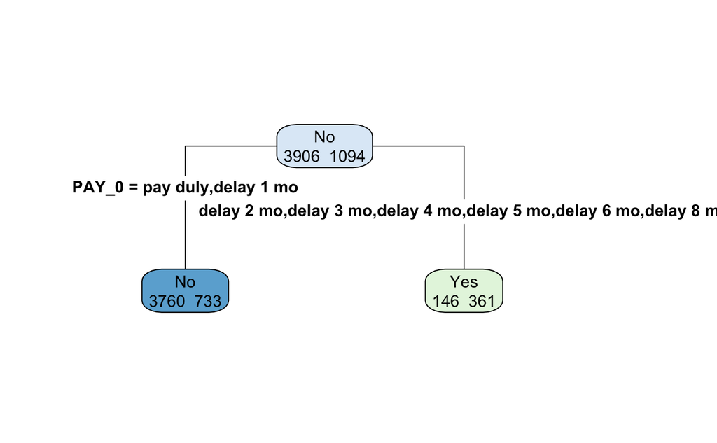

```r
rpart.plot(dtPay, type=4, extra=1)
```

Examine the decision tree visualization, explain what it means, and whether it is reasonable.

Answer:

From our training data set of 5000 records, the decision tree was built based on three repayment status variables which are PAY_0, PAY_2, and PAY_3.

- on the left side of the node, out of the total clients who pay duly and delay 1 month in repayment (4,493), the number of No for default in payment (3760) is higher than the number of yes for defaults in payment (733), so the decision for that node for default in payment is NO.

-on the right side of the node, out of the total clients who delay 2-8 months in repayment (507), the number of No for default in payment (146) is lower than the number of yes for default in payment (361), so the decision for that node for default in payment is YES

- On the root node, out of the total clients for all the repayment status variables (5000), the number of No for default in payment (3760 + 146 = 3906) is higher than the number of yes for default in payment (733 + 361 = 1094), so the final decision for the root node for default in payment is NO.

Final Thought: Yes the decision tree is reasonable.

```r
predict(nbPay, test[1,])
```

```
[1] No
Levels: No Yes
```

C.2. Decision Tree with a Different Complexity Parameter Rebuild the decision tree with a smaller cp (complexity parameter, please ?rpart.control in R console to know more about related parameters), for example:

```r
dtPay <- rpart(default.payment.next.month ~ PAY_0 + PAY_2 + PAY_3,
            method="class",
            data=train, parms=list(split='information'),
            minsplit=20, cp=0.001)
```

Repeat the steps in the C.1.

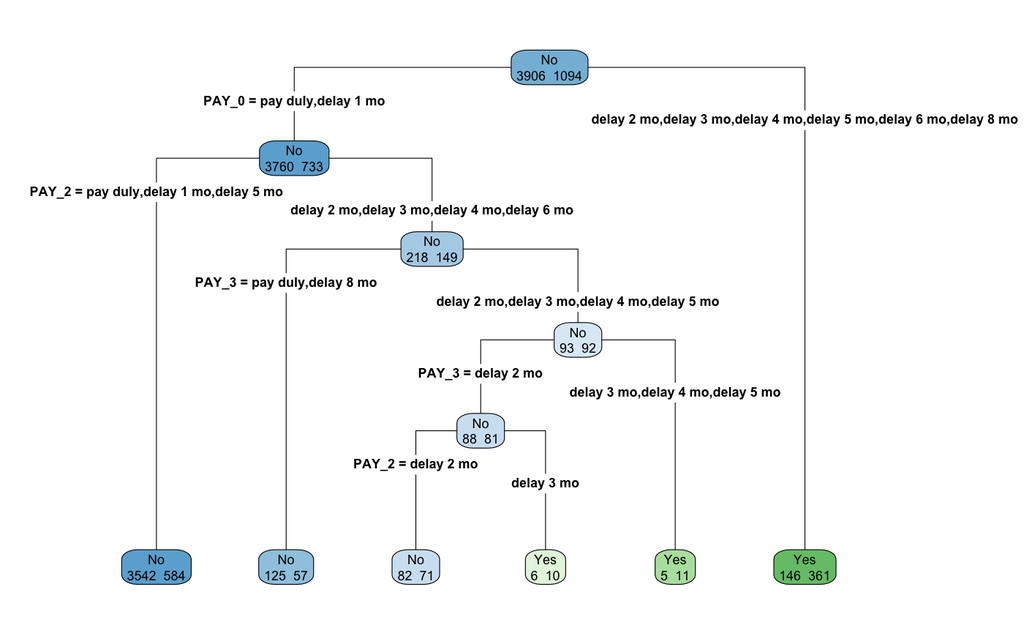

```r
rpart.plot(dtPay, type=4, extra=1)
```

```r
predict(nbPay, test[2,])
```

```
[1] No
Levels: No Yes
```

discuss the impact of the complexity parameter.

Answer:

The complexity parameter is used to control the size of the decision tree and select the optimal tree size. From my observation the higher the cp, the smaller and less complex the decision tree is. The smaller the cp, the more the decision tree is broken down into more nodes.

D. Conclusion

Compare the results based on the different models (with different parameters and using different variables). Which model appears to be better (best) given the stated problem and identified data?

Answer:

Naive Bayes model appears to be better for the stated problem and identified data.

Which one performs better on your two testing data rows?

If it predicts correctly, what (in the model and/or in the data) are helpful?

Answer:

The model considers attributes of the various variables (data) independently to determine the probability of getting a No or Yes for a client defaulting in payment.

Examining other variables not modeled in this assignment, what variables should be considered in the classification model (to predict default.payment.next.month)?

Answer:

variables not modeled in this assignment include: Age, bill_amt (1-6), Pay_amt(1-6) Variables that should be considered in the classification model is Age

In what ways they may be combined in the model? Please discuss your thinking and how you will proceed with further analysis.

Answer:

The Age variable could be combined with the sex variable to see what age range of males and females default in payment. In further analysis, I would combine the variables age, sex, and education to create a naive Bayes model that can give a more accurate probability of specific demography that have the highest probability of defaulting in payment.